# team

Brandon Xicon:xiconb,Eric Gleiter:Eric-Gleiter

3/17/2020

*Note that reading data and loading packages is hidden on the HTML for readabilty*

Loading Data: Cyclone Football

## Part one: Cleaning data

The three Excel sheets are loaded into R but they are not useful to us before some cleaning. Manipulate the three imported data frames, so that the cleaned data satisfy the following:

1. The player names and opponent names are factors.
2. All offensive and defensive statistics are numerical. The `Weight` column in Biography is also numeric. (Hint: look at `?mutate_at` if you want to save writing some code). 3.Change the ‘Height’ column in biography into numeric (Hint: Use a unit that works well)
3. By cleaning the three data frames in R, at the end of this step you should have the following three clean data frames: `defClean`, `offClean`, and `bioClean`. Print the structures of these data frames. **Make sure your data types make sense for each variable.**

```r
#player names and opponent names are factors
Bio$Name <- as.factor(Bio$Name)
Defense$Name <- as.factor(Defense$Name)
Offense$Name <- as.factor(Offense$Name)
Defense$Opponent_Opponent <- as.factor(Defense$Opponent_Opponent)
Offense$Opponent_Opponent <- as.factor(Offense$Opponent_Opponent)
```

```r
#offensive and defensive statistics are numerical. 'Weight' column in biography is also numeric.
Defense <- mutate_at(Defense, 3:11, as.numeric)
Offense <- mutate_at(Offense, 3:12, as.numeric)
Bio$Weight <- as.numeric(Bio$Weight)
defClean <- Defense
offClean <- Offense
str(defClean)
```

```
## Classes 'tbl_df', 'tbl' and 'data.frame':    502 obs. of  11 variables:
##  $ Name             : Factor w/ 43 levels "Akers, Landen",..: 40 40 40 40 40 40 40 40 40 40 ...
##  $ Opponent_Opponent: Factor w/ 13 levels "Baylor","Iowa",..: 12 2 11 1 8 13 10 7 6 9 ...
##  $ Tackles_Solo     : num  4 4 3 4 3 1 7 3 6 5 ...
##  $ Tackles_ASST     : num  4 7 5 2 2 1 1 2 1 5 ...
##  $ Tackles_TFL      : num  0 0 0 0 1 0 0 0 1 1 ...
##  $ Tackles_Sack     : num  0 0 0 0 0 0 0 0 0 1 ...
##  $ Turnover_FF      : num  0 0 0 0 0 0 0 0 0 0 ...
##  $ Turnover_FR      : num  0 0 0 0 0 0 0 0 0 0 ...
##  $ Turnover_INT     : num  0 0 1 0 0 0 0 0 1 0 ...
##  $ Pass_QBH         : num  1 0 0 0 0 0 0 0 1 0 ...
##  $ Pass_PB          : num  1 2 0 0 0 1 0 0 0 0 ...
```

```r
#Change Height column in biography into numeric
bioClean <- Bio %>% separate(Height, c("Feet", "Inches"))
bioClean$Feet = as.numeric(bioClean$Feet)
bioClean$Inches = as.numeric(bioClean$Inches)
bioClean$Height = (bioClean$Feet *12)+bioClean$Inches
bioClean = select(bioClean,-matches("Feet"))
bioClean = select(bioClean,-matches("Inches"))
bioClean <- bioClean[,c(1,2,7,3,4,5,6)]
head(bioClean)
```

```
## # A tibble: 6 x 7
##   Name          Position     Height Weight Class       Hometown       Highschool
##   <fct>         <chr>         <dbl>  <dbl> <chr>       <chr>          <chr>
## 1 Akers, Landen Wide Receiv~     72    188 Redshirt S~ Cedar Rapids,~ Washington
## 2 Allen, Chase  Tight End        79    245 Redshirt S~ Nixa, Mo.      Nixa
## 3 Anderson, Ez~ Wide Receiv~     77    204 Redshirt F~ Seffner, Fla.  Armwood
## 4 Assalley, Co~ Placekicker      72    195 Redshirt S~ Naperville, I~ Central
## 5 Azunna, Arno~ Defensive B~     72    190 Redshirt S~ Grand Prairie~ Lake Ridge
## 6 Bailey, Cord~ Defensive E~     75    235 Redshirt J~ Clarksdale, M~ Clarksdale
```

## Part two: Tidying (1)

For the following questions, work on the cleaned data frames defClean, offClean, and bioClean.

1. Reformat the defClean data frame into a tidy format using pivot_longer. The type of statistic (Tackles_Solo, Tackles_ASST, etc) is added as a new key column named Statistic.
2. Create a histogram for each defensive statistic. Use facet_wrap to draw all histograms in a single plot. What defensive skills are rare?

3.Did ISU have better defense against West Virginia or Kansas State? Answer this question by creating a scatterplot with x-axis being the number of solo tackles (by each player) against West Virginia, and y-axis being that against Kansas State. A large number of solo tackles indicates good defense.

```r
#Reformatting the defClean data frame into a tidy format also Changed Statistic to a factor for ease of use in the future
defClean <- defClean %>%
  pivot_longer(cols = c("Tackles_Solo","Tackles_Sack","Tackles_ASST", "Tackles_TFL","Turnover_FF", "Turnover_FR","Turnover_INT", "Pass_QBH","Pass_PB" ),
    names_to = "Statistic",
    values_to = "Value")
defClean$Statistic <- as.factor(defClean$Statistic)

str(defClean)
```

```
## Classes 'tbl_df', 'tbl' and 'data.frame':    4518 obs. of  4 variables:
##  $ Name             : Factor w/ 43 levels "Akers, Landen",..: 40 40 40 40 40 40 40 40 40 40 ...
##  $ Opponent_Opponent: Factor w/ 13 levels "Baylor","Iowa",..: 12 12 12 12 12 12 12 12 12 2 ...
##  $ Statistic        : Factor w/ 9 levels "Pass_PB","Pass_QBH",..: 5 4 3 6 7 8 9 2 1 5 ...
##  $ Value            : num  4 0 4 0 0 0 0 1 1 4 ...
```

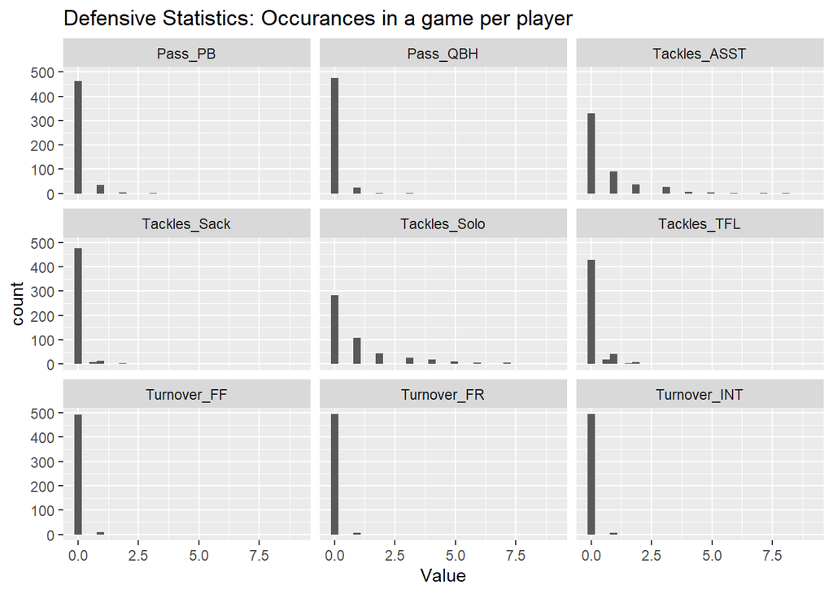

```r
#Creating a Histogram For each Defensice Statistic

ggplot(defClean, aes(x=Value)) +
  geom_histogram() +
  facet_wrap(defClean$Statistic) +
  labs(title = "Defensive Statistics: Occurances in a game per player",
       xlab= "Number of Occurances (Value)")
```

Looking at the histogram we see that almost all Stats have 0 as the majority howvever any Stat involing a turnover or sack is much more rare than other stats (IE the majority of players have 0 and almost no player has more than 1 in a game)

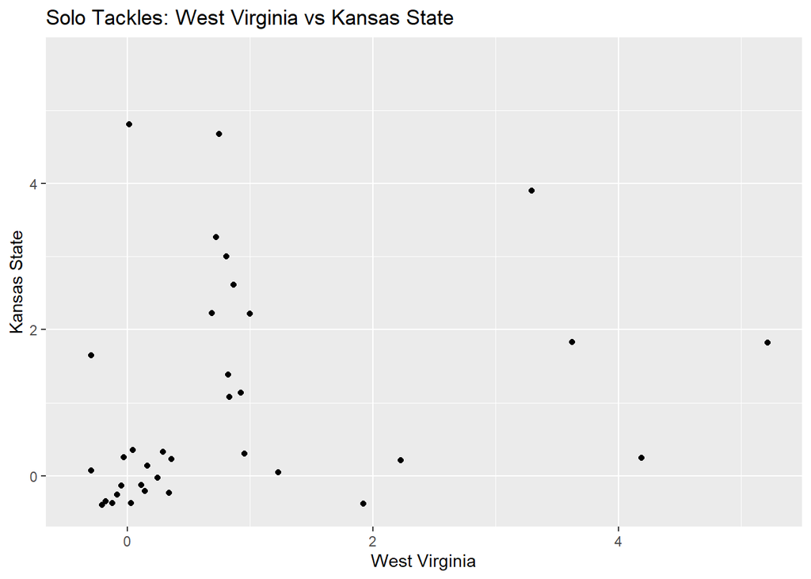

```r
#Did ISU have a better defense against West Virgina or Kanas State?
dat1 <- defClean
dat1 <- dat1 %>%
  filter(Opponent_Opponent == "West Virginia" | Opponent_Opponent == "Kansas State") %>%
  filter(Statistic == "Tackles_Solo") %>%
  pivot_wider(names_from = Opponent_Opponent, values_from = Value) %>%
  mutate( WV = `West Virginia` ) %>%
  mutate(KS = `Kansas State`)


ggplot(dat1, aes(x=WV, y=KS)) +
  geom_point(position = "jitter") +
  labs(title= "Solo Tackles: West Virginia vs Kansas State")+
  xlab("West Virginia") +
  ylab("Kansas State")
```

As you can see from the plot ISU had a better defense against Kansas State than against West Virginia, as more players had more solo tackles

## Part two: Tidying (2)

1. Separate the Hometown column into two columns, namely the city and the state. Print the first few rows of these two columns. (Hint: look at the sep= argument of separate)

2.How many players are there from each state?

```r
#Seperateing the Hometown Column into city and State
bioClean <- bioClean %>%
  separate(Hometown,into = c("City", "State"), sep= ',')
head(bioClean)
```

```
## # A tibble: 6 x 8
##   Name         Position    Height Weight Class       City      State  Highschool
##   <fct>        <chr>        <dbl>  <dbl> <chr>       <chr>     <chr>  <chr>
## 1 Akers, Land~ Wide Recei~     72    188 Redshirt S~ Cedar Ra~ " Iow~ Washington
## 2 Allen, Chase Tight End       79    245 Redshirt S~ Nixa      " Mo." Nixa
## 3 Anderson, E~ Wide Recei~     77    204 Redshirt F~ Seffner   " Fla~ Armwood
## 4 Assalley, C~ Placekicker     72    195 Redshirt S~ Napervil~ " Ill~ Central
## 5 Azunna, Arn~ Defensive ~     72    190 Redshirt S~ Grand Pr~ " Tex~ Lake Ridge
## 6 Bailey, Cor~ Defensive ~     75    235 Redshirt J~ Clarksda~ " Mis~ Clarksdale
```

```r
#HOw many Players in each State
dat2 <- bioClean
bioClean %>%
  count(State, sort = TRUE)
```

```
## # A tibble: 19 x 2
##    State            n
##    <chr>        <int>
##  1 " Iowa"         35
##  2 " Fla."         10
##  3 " Ohio"          7
##  4 " Mo."           6
##  5 " Texas"         6
##  6 " Wis."          6
##  7 " Ill."          5
##  8 " Ariz."         4
##  9 " Ga."           4
## 10 " Mich."         4
## 11 " Minn."         4
## 12 " Calif."        3
## 13 " Kan."          3
## 14 " Okla."         2
## 15 " S.D."          2
## 16 " Ark."          1
## 17 " Australia"     1
## 18 " Miss."         1
## 19 " Pa."           1
```

## Part Three: Joining data frames

1. Find where do the offensive players come from by joining the offensive data and player biography data appropriately.

```r
offJoined <- offClean %>%
  left_join(bioClean, by=c("Name"))
offCleanPlayers = offJoined %>%
  group_by(Name) %>%
  select(State)
head(offCleanPlayers)
```

```
## # A tibble: 6 x 2
## # Groups:   Name [1]
##   Name          State
##   <chr>         <chr>
## 1 Akers, Landen " Iowa"
## 2 Akers, Landen " Iowa"
## 3 Akers, Landen " Iowa"
## 4 Akers, Landen " Iowa"
## 5 Akers, Landen " Iowa"
## 6 Akers, Landen " Iowa"
```

2. Is there a relationship between the weight of a player and the receiving yards (Receiving_YDS)?

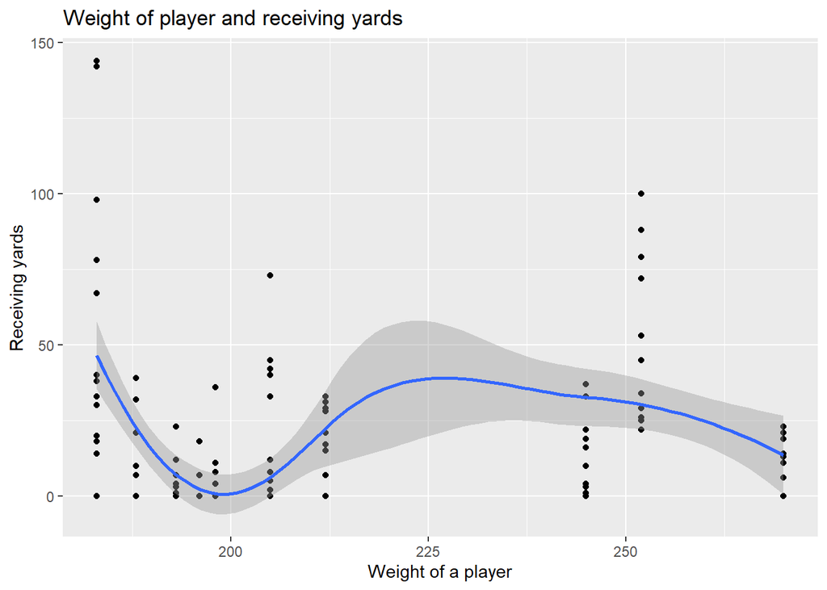

```r
ggplot(offJoined, aes(Weight, Receiving_YDS)) +
  geom_point() +
  labs(title = "Weight of player and receiving yards",
       x = "Weight of a player",
       y = "Receiving yards") +
  geom_smooth()
```

Based on the scatterplot and the geom_smooth() line we see that there is a dip around 190lbs and starts to increase around 200lbs where it peaks around 225 lbs (although there are no points it predicts the outcome) and slowly descreases from there as the relationship between weight and recieving yards.

3. How does the performance of quarterback Brock Purdy relate to the performance of the ISU team?

```r
offWithoutPurdy <- offClean %>%
  filter(Name != "Purdy, Brock") %>%
  group_by(Opponent_Opponent) %>%
  summarise_at(vars(-Name), funs(mean(.,na.rm = TRUE)))
head(offWithoutPurdy,13)
```

```
## # A tibble: 13 x 11
##    Opponent_Oppone~ Rushing_ATT Rushing_YDS Rushing_TD Receiving_REC
##    <fct>                  <dbl>       <dbl>      <dbl>         <dbl>
##  1 Baylor                  2.5        10         0.167          2.08
##  2 Iowa                    1.67        9.5       0              1.92
##  3 Kansas                  5.17       18.2       0.167          2.07
##  4 Kansas State            3           9.83      0.167          1.15
##  5 Notre Dame              2.86        8.71      0              1.5
##  6 Oklahoma                3.67       23.7       0              1.46
##  7 Oklahoma State          3.33       14.2       0.333          2.79
##  8 TCU                     2.75       11.4       0.25           1.27
##  9 Texas                   4.17       17.7       0              2.14
## 10 Texas Tech              3.33       29.8       0.333          1.64
## 11 ULM                     3.38       24.9       0.125          1.47
## 12 UNI                     7.17       32.7       0.167          2.31
## 13 West Virginia           4.86       23         0.429          1.27
## # ... with 6 more variables: Receiving_YDS <dbl>, Receiving_TD <dbl>,
## #   `Passing_CMP-ATT` <dbl>, Passing_YDS <dbl>, Passing_TD <dbl>,
## #   Passing_INT <dbl>
```

```r
justPurdy <- offClean %>%
  filter(Name == "Purdy, Brock")

head(justPurdy,13)
```

```
## # A tibble: 13 x 12
##    Name  Opponent_Oppone~ Rushing_ATT Rushing_YDS Rushing_TD Receiving_REC
##    <fct> <fct>                  <dbl>       <dbl>      <dbl>         <dbl>
##  1 Purd~ UNI                        2         -11          0            NA
##  2 Purd~ Iowa                       9          34          0            NA
##  3 Purd~ ULM                        9          75          3            NA
##  4 Purd~ Baylor                    13           3          0            NA
##  5 Purd~ TCU                       12         102          2            NA
##  6 Purd~ West Virginia              6         -15          1            NA
##  7 Purd~ Texas Tech                 3           7          0            NA
##  8 Purd~ Oklahoma State             5           1          0            NA
##  9 Purd~ Oklahoma                  15          55          1            NA
## 10 Purd~ Texas                      4           8          0            NA
## 11 Purd~ Kansas                     3           9          1            NA
## 12 Purd~ Kansas State               5          -3          0            NA
## 13 Purd~ Notre Dame                 7         -16          0            NA
## # ... with 6 more variables: Receiving_YDS <dbl>, Receiving_TD <dbl>,
## #   `Passing_CMP-ATT` <dbl>, Passing_YDS <dbl>, Passing_TD <dbl>,
## #   Passing_INT <dbl>
```

With Regards to rushing the team’s preformance does not seem to depend on purdy’s own preformance however the when it comes to passing/recieving it seems that the teams preformance is very much tied to purdy’s where the better he is doing the better the team is doing.

4. Explore more. Raise a question that can be answered only by looking at two or more data frames. Then answer that question.

**Which State produces the best offensive players?**

```r
dat1 <- offJoined %>%
  group_by(State) %>%
  summarise_at(vars(c("Rushing_YDS","Receiving_YDS")), funs(mean(.,na.rm = TRUE)))

dat1
```

```
## # A tibble: 12 x 3
##    State    Rushing_YDS Receiving_YDS
##    <chr>          <dbl>         <dbl>
##  1 " Ariz."      19.2         NaN
##  2 " Ark."      NaN             8.92
##  3 " Fla."       19.8          31.0
##  4 " Ga."       NaN             4.54
##  5 " Ill."       12           NaN
##  6 " Iowa"        0.615         8.38
##  7 " Kan."       74.8          21
##  8 " Mo."       NaN            12.8
##  9 " Ohio"      NaN             2.5
## 10 " Okla."     NaN            38.7
## 11 " Texas"       8.85          0.615
## 12  <NA>          6.63         37.6
```

Looking at the Rushing and Recevining Yards since those two things are what offense is all about, we can see that our players from Kansas are the best as they have a whooping 74.75 Rushing yards average and are number 4 in terms of passing yards. This means that either matt campbell found a couple gems in kansas or he should be doing more recruitment in that state.